# Sixth Week: Linear Models

House price prediction

امین رخشا ۹۵۱۰۹۳۱۵

2018-04-13 23:17:21

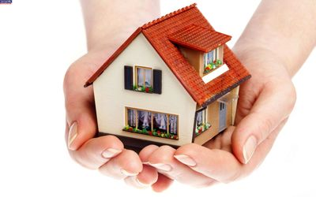

> با توجه به داده های قیمت منازل لطفا با سوالات زیر پاسخ دهید.

کارهای اولیه

```r
library(readr)
library(dplyr)
library(tidyr)
library(psych)
library(reshape2)
library(corrplot)
library(ggplot2)
library(ggthemes)
theme_set(theme_gdocs())
house = read_csv('train.csv') %>% select(-Id)
```

۱. ماتریس همبستگی متغیرهای مختلف را به دست آورده و سپس رسم نمایید. اعداد به دست آمده را با آزمون فرض معناداری همبستگی بسنجید و سپس ده متغیری که همبستگی بالاتری با قیمت دارند را مشخص نمایید.

با توجه به این که همبستگی بین متغیرهای عددی تعریف می شود، تنها این متغیرها را نگه می داریم. البته می توان مانند کاری که در ساخت مدل با متغیرهای کیفی می کنیم یعنی ساخت تعدادی متغیر جدید برای هر مقدار را انجام دهیم ولی همبستگی برای متغیر با دو مقدار ۰ و ۱ هم جالب نیست. نتیجه محاسبه ماتریس همبستگی را در زیر می بینید:

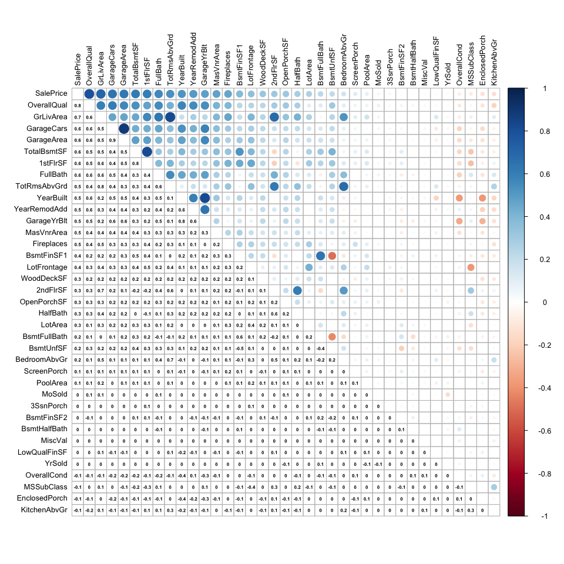

```r
numericVarnames = colnames(house)[sapply(house, typeof) == 'integer']
numericVars = house %>%
  select(numericVarnames)

corr_mat = cor(numericVars, use="pairwise.complete.obs")
#sort on decreasing correlations with SalePrice
cor_sorted <- as.matrix(sort(corr_mat[,'SalePrice'], decreasing = TRUE))
#select only high corelations
CorHigh <- names(which(apply(cor_sorted, 1, function(x) TRUE)))
corr_mat <- corr_mat[CorHigh, CorHigh]

p_mat = corr_mat
for(varName1 in numericVarnames) {
  for(varName2 in numericVarnames) {
    p_mat[varName1, varName2] = cor.test(numericVars[[varName1]], numericVars[[varName2]])$p.value
  }
}


corrplot.mixed(corr_mat, tl.col="black", tl.pos = "lt", tl.cex = 0.8,
               number.cex = 0.5, number.digits = 1, lower.col = 'black')
```

با استفاده از cor.test تمام این ضرایب را بررسی می کنیم. نتیجه ی دقیق در ماتریس p_mat در دسترس است. نتیجه نهایی در مورد این که هر ضریب در چه significance level ی قرار دارد را در زیر می بینید.

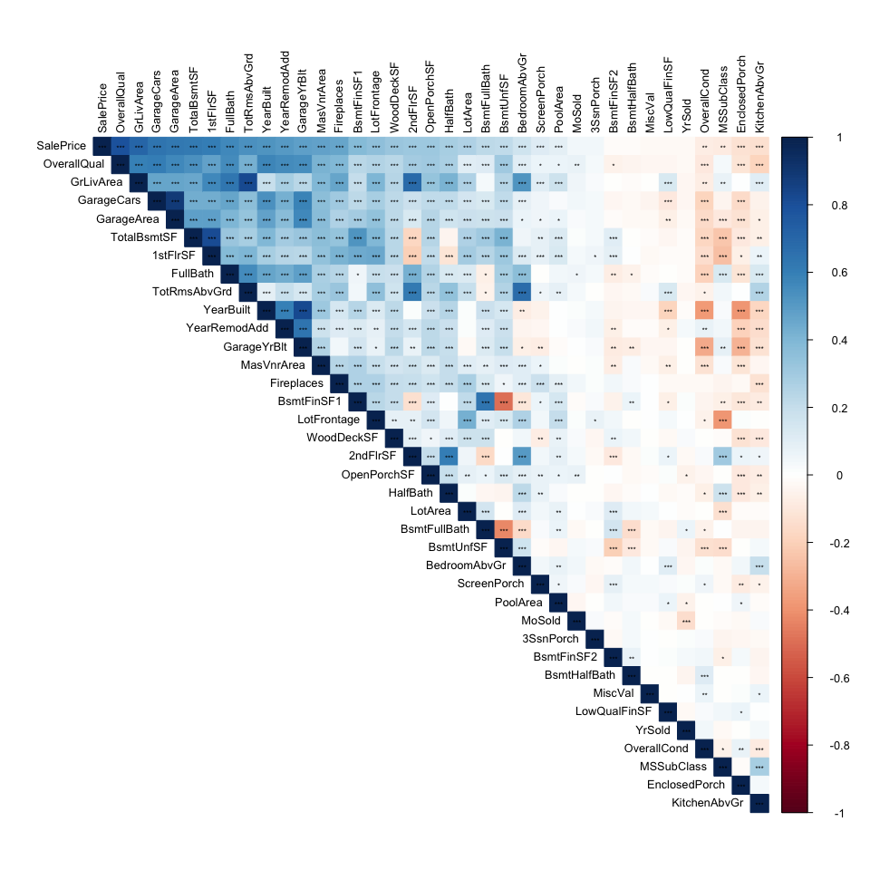

```r
corrplot(corr_mat, p.mat = p_mat, tl.col="black", sig.level = c(.001, .01, .05), tl.cex = 0.8,
         insig = "label_sig", pch.cex = .5, type = 'upper', method = 'color',
         number.cex = 0.5, number.digits = 1, lower.col = 'black')
```

۱۰ متغیر با بیشترین همبستگی را جدا و برای بررسی دقیقتر ماتریس همبستگی آن ها را می کشیم:

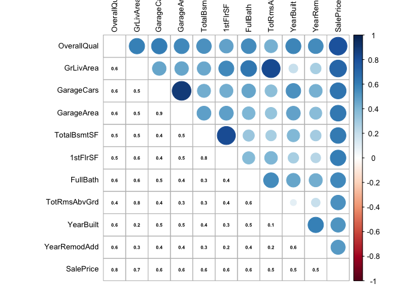

```r
corr_tidy = melt(corr_mat)
topVarsCor = corr_tidy %>%
  filter(Var2 == 'SalePrice', Var1 != 'SalePrice') %>%
  arrange(desc(value)) %>%
  slice(1:10) %>%
  select(var = Var1, cor = value)

topVars = as.character(topVarsCor$var)

selected = house %>% select(topVars, SalePrice)

selected_corr_mat = cor(selected)
corrplot.mixed(selected_corr_mat, tl.col="black", tl.pos = "lt", tl.cex = 0.8,
               number.cex = 0.5, number.digits = 1, lower.col = 'black')
```

۲. در یک تصویر نمودار پراکنش دو به دو ده متغیر بدست آمده به همراه قیمت را رسم نمایید و هم خطی بودن متغیرها را بررسی کنید

تمام نمودارها را می کشیم:

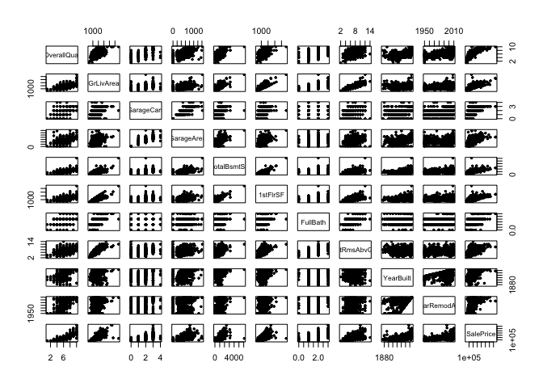

```r
pairs(selected, pch = 19, cex = 0.5)
```

می بینیم که بعضی متغیرها رابطه خطی زیادی دارند. مانند مساحت زیرزمین و مساحت طبقه اول. برای بررسی دقیق تر از تست omcdiag استفاده می کنیم. این تست هم وجود هم خطی بین بعضی از متغیرها را تایید می کند.

```r
library(mctest)
omcdiag(selected %>% select(-SalePrice), selected %>% select(SalePrice))
```

```
##
## Call:
## omcdiag(x = selected %>% select(-SalePrice), y = selected %>%
##     select(SalePrice))
##
##
## Overall Multicollinearity Diagnostics
##
##                        MC Results detection
## Determinant |X'X|:         0.0007         1
## Farrar Chi-Square:     10652.4387         1
## Red Indicator:             0.4852         0
## Sum of Lambda Inverse:    34.9056         0
## Theil's Method:           -0.2152         0
## Condition Number:        545.2532         1
##
## 1 --> COLLINEARITY is detected by the test
## 0 --> COLLINEARITY is not detected by the test
```

۳. یک مدل خطی بر اساس ده متغیر برای پیش بینی قیمت برازش دهید. و سپس خلاصه نتایج مدل را به دست آورید.

با دستور lm مدل را محاسبه می کنیم

```r
model1 = lm(data = selected,
            SalePrice ~ . )
summary(model1)
```

```
##
## Call:
## lm(formula = SalePrice ~ ., data = selected)
##
## Residuals:
##     Min      1Q  Median      3Q     Max
## -489958  -19316   -1948   16020  290558
##
## Coefficients:
##                Estimate Std. Error t value Pr(>|t|)
## (Intercept)  -1.186e+06  1.291e+05  -9.187  < 2e-16 ***
## OverallQual   1.960e+04  1.190e+03  16.472  < 2e-16 ***
## GrLivArea     5.130e+01  4.233e+00  12.119  < 2e-16 ***
## GarageCars    1.042e+04  3.044e+03   3.422 0.000639 ***
## GarageArea    1.495e+01  1.031e+01   1.450 0.147384
## TotalBsmtSF   1.986e+01  4.295e+00   4.625 4.09e-06 ***
## `1stFlrSF`    1.417e+01  4.930e+00   2.875 0.004097 **
## FullBath     -6.791e+03  2.682e+03  -2.532 0.011457 *
## TotRmsAbvGrd  3.310e+01  1.119e+03   0.030 0.976404
## YearBuilt     2.682e+02  5.035e+01   5.328 1.15e-07 ***
## YearRemodAdd  2.965e+02  6.363e+01   4.659 3.47e-06 ***
## ---
## Signif. codes:  0 '***' 0.001 '**' 0.01 '*' 0.05 '.' 0.1 ' ' 1
##
## Residual standard error: 37920 on 1449 degrees of freedom
## Multiple R-squared:  0.7737, Adjusted R-squared:  0.7721
## F-statistic: 495.4 on 10 and 1449 DF,  p-value: < 2.2e-16
```

۴. نمودار قیمت واقعی و قیمت پیش بینی را رسم نمایید و خوب بودن مدل را ارزیابی کنید.

نمودار پراکنش را رسم می کنیم. باید نقاط نزدیک به خط y = x که رسم کرده ایم باشند که تقریبا این طور است و به طور کلی بد عمل نمی کند. برای خانه های با قیمت بالا اما مقدار پیشبینی کمتر از واقعیت است.

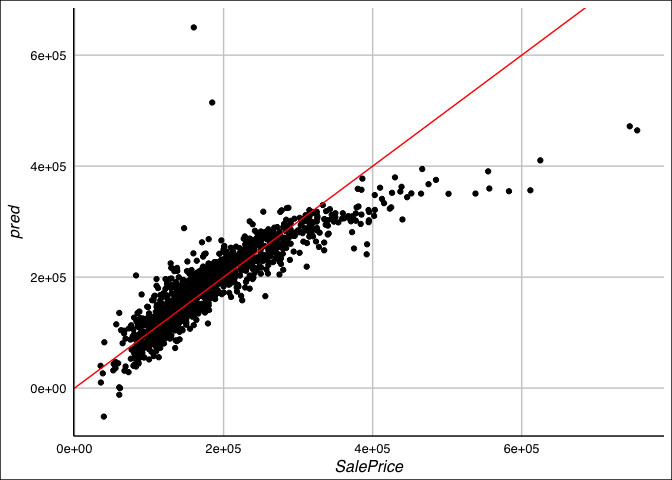

```r
RealVSPred = selected %>% mutate(pred = fitted(model1)) %>% select(SalePrice, pred)
ggplot(RealVSPred, aes(x = SalePrice, y = pred)) +
  geom_point() +
  geom_abline(slope = 1, intercept = 0, color = 'red')
```

۵. مقدار R-squared مدل را به دست آورید. آیا بر اساس این کمیت مدل به خوبی به داده ها برازش داده شده است؟ کمیت F-statistic را در خلاصه مدل تفسیر نمایید.

مقدار R-squared را با استفاده از رابطه ی آن محاسبه می کنیم. می بینیم که با مقدار آن در خلاصه ی مدل مطابق است. این مقدار برابر ۰.۸ که مقدار نسبتا بالایی است و می توان گفت مدل به خوبی برازش شده است. F-statistics این را می سنجد که آیا متغیرهای ما ربطی به مقداری که میخواهیم پیشبینی کنیم داریم یا نه! به طور دقیقتر آیا این مدل از یک مدل با تنها یک عدد ثابت بهتر هست یا نه. که با توجه به مقدار بسیار کم p-value آن، فرض صفر که مدل مانند مدل با تنها یک عدد ثابت است و هیچ یک از متغیرهایمان مربوط نیستند همانطور که انتظار داریم رد می شود.

```r
y = selected$SalePrice
rsquare = sum((fitted(model1) - mean(y))^2) / sum((y - mean(y))^2)
rsquare
```

```
## [1] 0.7736928
```

۶. بر اساس p-value سطح معناداری ضرایب تصمیم بگیرید که چه متغیرهایی در مدل سازی استفاده شود. بر اساس متغیرهای جدید دوباره مدل سازی کنید و نتایج رو گزارش دهید.

```r
model2 = lm(data = selected,
            SalePrice ~ . - GarageArea - TotRmsAbvGrd)
summary(model2)
```

```
##
## Call:
## lm(formula = SalePrice ~ . - GarageArea - TotRmsAbvGrd, data = selected)
##
## Residuals:
##     Min      1Q  Median      3Q     Max
## -482525  -19191   -1801   16208  289639
##
## Coefficients:
##                Estimate Std. Error t value Pr(>|t|)
## (Intercept)  -1.188e+06  1.284e+05  -9.255  < 2e-16 ***
## OverallQual   1.959e+04  1.188e+03  16.486  < 2e-16 ***
## GrLivArea     5.177e+01  3.097e+00  16.714  < 2e-16 ***
## GarageCars    1.395e+04  1.817e+03   7.680 2.92e-14 ***
## TotalBsmtSF   2.039e+01  4.269e+00   4.775 1.98e-06 ***
## `1stFlrSF`    1.465e+01  4.919e+00   2.979  0.00294 **
## FullBath     -7.184e+03  2.644e+03  -2.717  0.00666 **
## YearBuilt     2.699e+02  5.017e+01   5.380 8.69e-08 ***
## YearRemodAdd  2.957e+02  6.362e+01   4.649 3.64e-06 ***
## ---
## Signif. codes:  0 '***' 0.001 '**' 0.01 '*' 0.05 '.' 0.1 ' ' 1
##
## Residual standard error: 37920 on 1451 degrees of freedom
## Multiple R-squared:  0.7734, Adjusted R-squared:  0.7721
## F-statistic: 618.9 on 8 and 1451 DF,  p-value: < 2.2e-16
```

۷. مدل خود را بر اساس باقی مانده نقص یابی کنید. سه محک normality, independance, Constant Variance را در نقص یابی خود در نظر بگیرید.

برای بررسی constant variance و independence نمودارهای زیر را می کشیم. این نمودارها پراکنش باقیمانده بر اساس مقدار پیشبینی نشان می دهند. با این تفاوت که نمودار دوم آن را براساس انحراف معیار آن ها نرمال کرده است. برای برقراری independence انتظار داریم میانگین پراکندگی باقیمانده ها برای مقادیر مختلف پیشبینی یکسان باشد. و برای constant variance میزان فاصله نقاط از خط قرمز به طور کلی یکسان باشد. در مدل ما مشاهده می کنیم که واریانس در نزدیکی ۲۵۰۰۰۰ بیشتر از نزدیکی ۱۰۰۰۰ است و خیلی شرط constant variance برقرار نیست. همینطور مقدار میانگین و پراکنش هم برای مقادیر مختلف پیشبینی تا حدی تغییر می کند پس شرط independence هم به طور کامل برقرار نیست. اما اوضاع خیلی هم بد نیست و می توان هنوز از مدل خطی با مقداری خطا استفاده کرد.

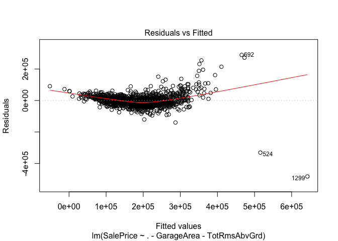

```r
#independance & constant covariance
plot(model2, which = 1)
```

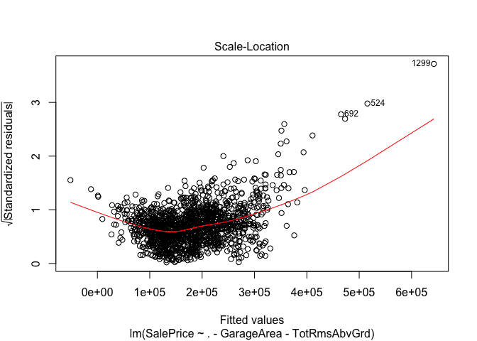

```r
plot(model2, which = 3)
```

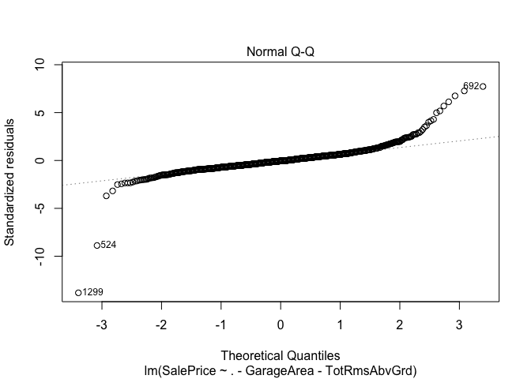

```r
#normality
plot(model2, which = 2)
```

۸. داده ها را به پنج قسمت تقسیم کنید. بر اساس چهار قسمت مدل خطی را بسازید و صحت مدل را برای یک قسمت باقی مانده را تست کنید. خطای پیش بینی شما چقدر است؟

```r
n <- nrow(selected)
set.seed(17)
part1indexes = sample(1:n, 4 * n / 5)
part1 = selected %>% slice(part1indexes)
part2 = selected %>% slice(-part1indexes)

model3 = lm(data = part1,
            SalePrice ~ . - GarageArea - TotRmsAbvGrd)

MSE = mean((part2$SalePrice - predict.lm(model3, part2))^2)
MSE
```

```
## [1] 1534057480
```

```r
sqrt(MSE)
```

```
## [1] 39167.05
```

۹. آیا قیمت ربط غیر خطی با یکی از ده متغیر استفاده شده دارد؟ بر اساس دستاوردهای خود مدل را بهتر نمایید.

نمودارهای پراکنش قیمت و متغیرها را رسم می کنیم. در نمودارها خط قرمز بهترین خط گذرنده و خط سبز تغییرات کلی را نشان می دهد. می بینیم که به جز دو متغیر OverallQual و YearBuilt بقیه ی متغیرها تا حد خوبی رابطه ی خطی دارند.

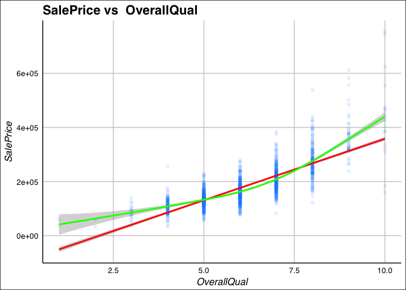

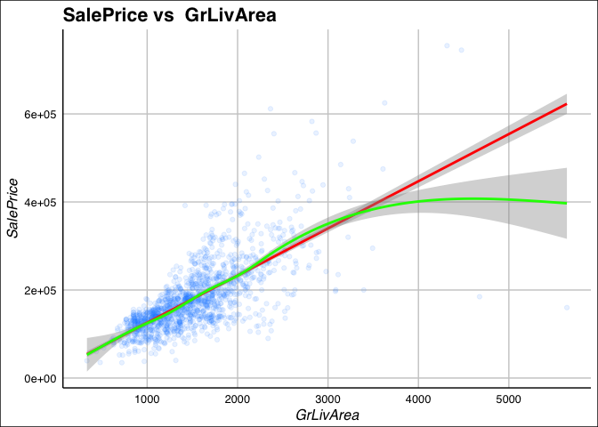

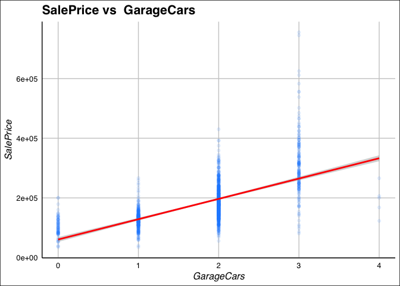

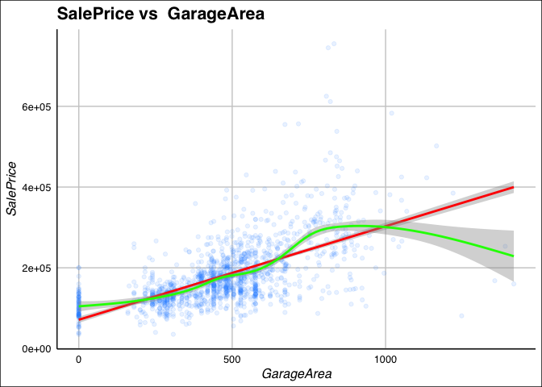

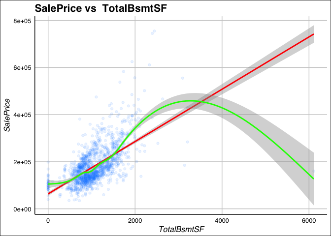

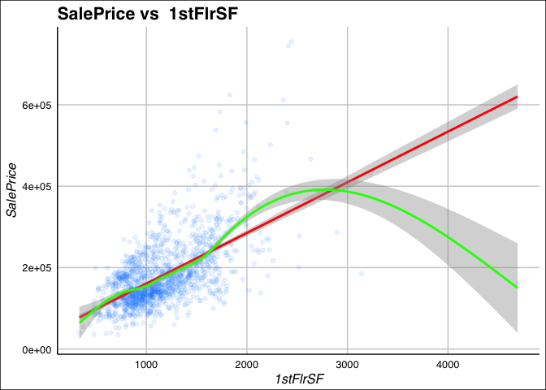

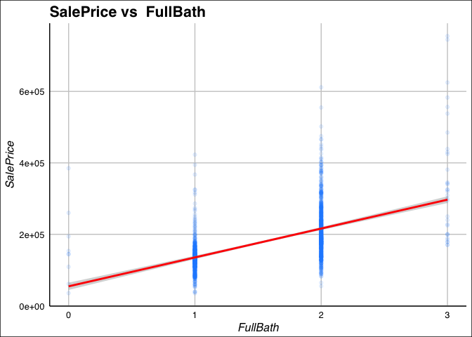

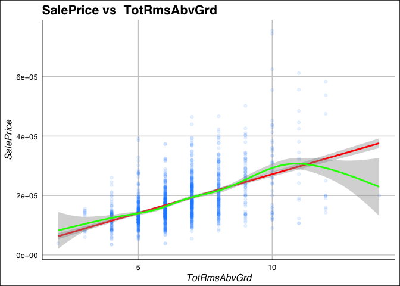

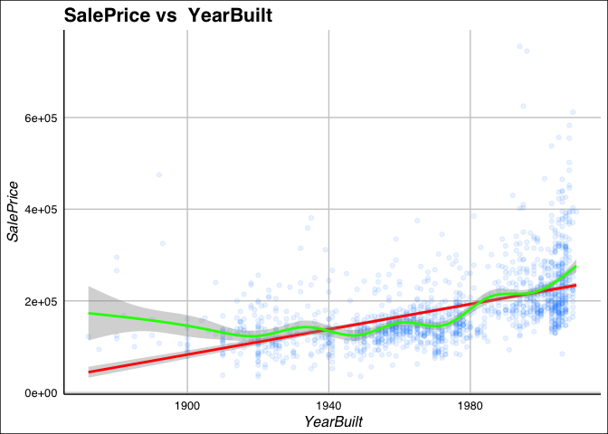

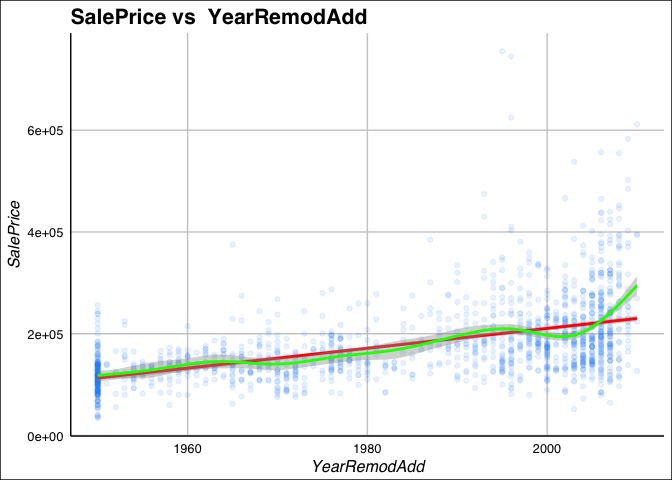

```r
for(varName in topVarsCor$var) {
  p = ggplot(selected, aes(y = SalePrice, x = selected[[varName]])) +
    geom_point(color = 'dodgerblue', alpha = 0.1) +
    geom_smooth(method = 'lm', color = 'red') +
    geom_smooth(color = 'green') +
    labs(title = paste('SalePrice vs ', varName), x = varName)
  print(p)
}
```

برای حل این مشکل معمولا یک تبدیل غیر خطی روی متغیرها اعمال میکنند. از روی نمودار حدس میزنیم که قیمت با توان دوم قدمت رابطه دارد. (تبدیل خطی تفاوتی ایجاد نمی کند. برای همین به جای سال ساخت با سن کار می کنیم.) برای همین بهترین سهمی را از آن می گذراینم و بر اساس آن تبدیلی با چندجمله ای درجه ۲ اعمال می کنیم تا رابطه خطی شود.

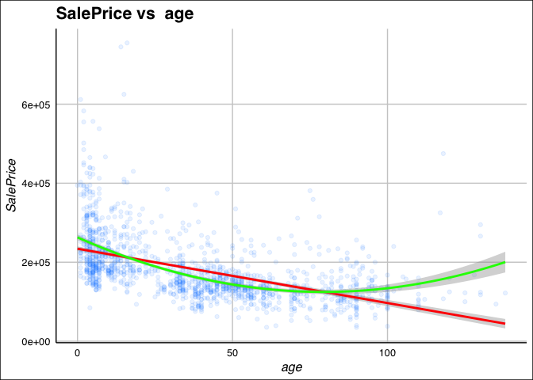

```r
PriceVsAge = house %>% filter(-1299, -524) %>%
  mutate(age = 2010 - YearBuilt) %>%
  select(age, SalePrice)

varName = 'age'
ggplot(PriceVsAge, aes(y = SalePrice, x = age)) +
  geom_point(color = 'dodgerblue', alpha = 0.1) +
  geom_smooth(method = 'lm', color = 'red') +
  geom_smooth(method = 'lm', formula = y ~ x + I(x^2),color = 'green') +
  labs(title = paste('SalePrice vs ', varName), x = varName)
```

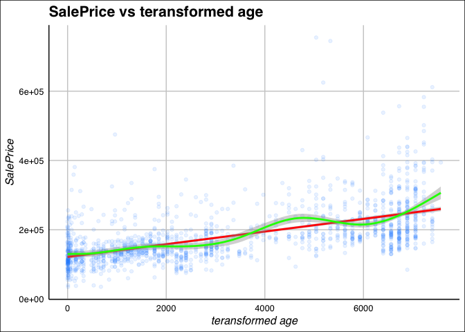

```r
ageModel = lm(PriceVsAge, formula = SalePrice ~ age + I(age^2))
# summary(ageModel)

PriceVsAge$age = (PriceVsAge$age - 87)^2
ggplot(PriceVsAge, aes(y = SalePrice, x = age)) +
  geom_point(color = 'dodgerblue', alpha = 0.1) +
  geom_smooth(method = 'lm', color = 'red') +
  geom_smooth(color = 'green') +
  labs(title = paste('SalePrice vs teransformed age'), x = 'teransformed age')
```

برای OverallQual هم به طور مشابه عمل می کنیم:

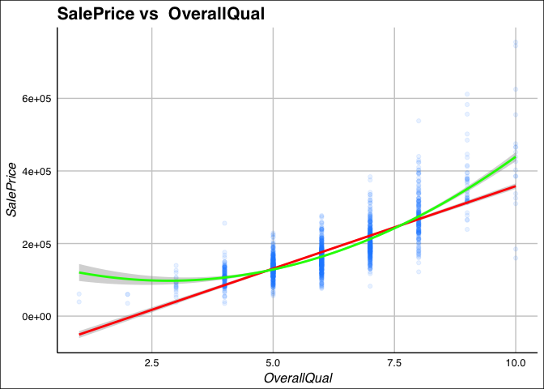

```r
PriceVsQual = house %>% filter(-1299, -524) %>%
  select(OverallQual, SalePrice)

varName = 'OverallQual'
ggplot(PriceVsQual, aes(y = SalePrice, x = OverallQual)) +
  geom_point(color = 'dodgerblue', alpha = 0.1) +
  geom_smooth(method = 'lm', color = 'red') +
  geom_smooth(method = 'lm', formula = y ~ x + I(x^2),color = 'green') +
  labs(title = paste('SalePrice vs ', varName), x = varName)
```

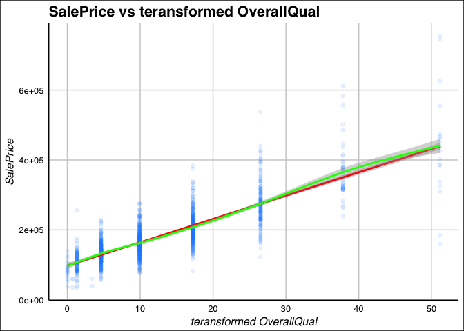

```r
OQModel = lm(PriceVsQual, formula = SalePrice ~ OverallQual + I(OverallQual^2))
# summary(OQModel)

PriceVsQual$OverallQual = (PriceVsQual$OverallQual - 2.85)^2


varName = 'OverallQual'
ggplot(PriceVsQual, aes(y = SalePrice, x = OverallQual)) +
  geom_point(color = 'dodgerblue', alpha = 0.1) +
  geom_smooth(method = 'lm', color = 'red') +
  geom_smooth(color = 'green') +
  labs(title = paste('SalePrice vs teransformed OverallQual'), x = 'teransformed OverallQual')
```

مدل را با این تغییرات بهبود می دهیم:

```r
transformed = selected %>% rename(age = YearBuilt)
transformed$age = PriceVsAge$age
transformed$OverallQual = PriceVsQual$OverallQual

model4 = lm(data = transformed,
            SalePrice ~ .- GarageArea - TotRmsAbvGrd)
summary(model4)
```

```
##
## Call:
## lm(formula = SalePrice ~ . - GarageArea - TotRmsAbvGrd, data = transformed)
##
## Residuals:
##     Min      1Q  Median      3Q     Max
## -487912  -17475     -25   15577  258506
##
## Coefficients:
##                Estimate Std. Error t value Pr(>|t|)
## (Intercept)  -6.163e+05  1.271e+05  -4.847 1.38e-06 ***
## OverallQual   3.435e+03  1.632e+02  21.044  < 2e-16 ***
## GrLivArea     4.411e+01  2.916e+00  15.124  < 2e-16 ***
## GarageCars    1.445e+04  1.736e+03   8.321  < 2e-16 ***
## TotalBsmtSF   1.937e+01  4.092e+00   4.733 2.43e-06 ***
## `1stFlrSF`    1.134e+01  4.745e+00   2.389   0.0170 *
## FullBath     -3.859e+03  2.585e+03  -1.493   0.1357
## age           1.331e+00  6.883e-01   1.934   0.0533 .
## YearRemodAdd  3.174e+02  6.471e+01   4.906 1.04e-06 ***
## ---
## Signif. codes:  0 '***' 0.001 '**' 0.01 '*' 0.05 '.' 0.1 ' ' 1
##
## Residual standard error: 36190 on 1451 degrees of freedom
## Multiple R-squared:  0.7936, Adjusted R-squared:  0.7925
## F-statistic: 697.4 on 8 and 1451 DF,  p-value: < 2.2e-16
```

۱۰. بر اساس مدل نهایی به دست آمده نتایج پیش بینی خود را بر روی test.csv به دست آورید و در سایت kaggle در مسابقه House Prices: Advanced Regression Techniques بارگذاری نمایید. سپس لینک رتبه و عدد آن را ضمیمه تمرین کنید.

قبل از سابمیت کردن، مدل را مقداری تغییر می دهیم. ابتدا بر اساس YrSold و YearBuilt سن را حساب کردیم و مانند سوال ۹ فرض را بر فروش در سال ۲۰۱۰ نگذاشتیم. با توجه به محدودیت سوال ۱، تنها از متغیرهای عددی استفاده کرده بودیم. متغیرهای Neighborhood و MSSubClass و OverallCond را به مدل اضافه می کنیم. برای برخی مشاهدات که اطلاعات کامل نیست، میانگین ستون مورد نظر را جایگزین می کنیم.

```r
finalVars = house %>%
  select(topVars, SalePrice, Neighborhood, OverallCond, MSSubClass, YrSold) %>%
  select(-GarageArea , -TotRmsAbvGrd) %>%
  mutate(age = YearBuilt - YrSold,
         remoded = ifelse(YearBuilt == YearRemodAdd, 0, 1),
         OverallQual = (OverallQual - 2.85)^2) %>%
  select(-YearBuilt, - YearRemodAdd, -YrSold) %>%
  filter(-1299, -524)
finalVars$MSSubClass = as.factor(finalVars$MSSubClass)

finalModel = lm(SalePrice ~ .,
                data = finalVars)
# summary(finalModel)
test = read_csv('test.csv')
test = test %>%
  mutate(age = YearBuilt - 2010,
         remoded = ifelse(YearBuilt == YearRemodAdd, 0, 1),
         OverallQual = (OverallQual - 2.85)^2 ) %>%
  select(Id, topVars, age, Neighborhood, remoded, OverallCond, MSSubClass) %>%
  select(-YearBuilt, - YearRemodAdd)
test$MSSubClass = as.factor(test$MSSubClass)
test[661, "TotalBsmtSF"] = mean(test$TotalBsmtSF, na.rm = TRUE)
test[1117, "GarageCars"] = mean(test$GarageCars, na.rm = TRUE)
test[1359, "MSSubClass"] = 120
testPred = predict.lm(finalModel, test)
result = data.frame(Id = test$Id, SalePrice = testPred)
write_csv(result, 'result.csv')
```

نتیجه را آپلود می کنیم. رتبه ی ۲۷۸۲ به دست می آید:

[figure not shown]